# R Notebook

# 1. Exercise

For the prostate data infaraway, fit a model with lpsa as the response and the other variables as predictors.

Compute 90% and 95% CIs for the parameter associated with age

```r
library("faraway")
data(prostate)
head(prostate)
```

```
##       lcavol lweight age      lbph svi      lcp gleason pgg45     lpsa
## 1 -0.5798185  2.7695  50 -1.386294   0 -1.38629       6     0 -0.43078
## 2 -0.9942523  3.3196  58 -1.386294   0 -1.38629       6     0 -0.16252
## 3 -0.5108256  2.6912  74 -1.386294   0 -1.38629       7    20 -0.16252
## 4 -1.2039728  3.2828  58 -1.386294   0 -1.38629       6     0 -0.16252
## 5  0.7514161  3.4324  62 -1.386294   0 -1.38629       6     0  0.37156
## 6 -1.0498221  3.2288  50 -1.386294   0 -1.38629       6     0  0.76547
```

```r
g <- lm(lpsa ~ ., prostate)
summary(g)
```

```
##
## Call:
## lm(formula = lpsa ~ ., data = prostate)
##
## Residuals:
##     Min      1Q  Median      3Q     Max
## -1.7331 -0.3713 -0.0170  0.4141  1.6381
##
## Coefficients:
##              Estimate Std. Error t value Pr(>|t|)
## (Intercept)  0.669337   1.296387   0.516  0.60693
## lcavol       0.587022   0.087920   6.677 2.11e-09 ***
## lweight      0.454467   0.170012   2.673  0.00896 **
## age         -0.019637   0.011173  -1.758  0.08229 .
## lbph         0.107054   0.058449   1.832  0.07040 .
## svi          0.766157   0.244309   3.136  0.00233 **
## lcp         -0.105474   0.091013  -1.159  0.24964
## gleason      0.045142   0.157465   0.287  0.77503
## pgg45        0.004525   0.004421   1.024  0.30886
## ---
## Signif. codes:  0 '***' 0.001 '**' 0.01 '*' 0.05 '.' 0.1 ' ' 1
##
## Residual standard error: 0.7084 on 88 degrees of freedom
## Multiple R-squared:  0.6548, Adjusted R-squared:  0.6234
## F-statistic: 20.86 on 8 and 88 DF,  p-value: < 2.2e-16
```

```r
(cf <- summary(g)$coef)
```

```
##                 Estimate  Std. Error    t value     Pr(>|t|)
## (Intercept)  0.669336698 1.296387471  0.5163091 6.069335e-01
## lcavol       0.587021826 0.087920303  6.6767493 2.110698e-09
## lweight      0.454467424 0.170012435  2.6731423 8.955363e-03
## age         -0.019637176 0.011172725 -1.7575995 8.229321e-02
## lbph         0.107054031 0.058449214  1.8315735 7.039846e-02
## svi          0.766157326 0.244309148  3.1360157 2.328749e-03
## lcp         -0.105474263 0.091013487 -1.1588861 2.496377e-01
## gleason      0.045141598 0.157464523  0.2866779 7.750328e-01
## pgg45        0.004525231 0.004421179  1.0235350 3.088604e-01
```

```r
confint(g, level = 0.90)
```

```
##                      5 %         95 %
## (Intercept) -1.485718237  2.824391633
## lcavol       0.440867156  0.733176497
## lweight      0.171846568  0.737088281
## age         -0.038210200 -0.001064151
## lbph         0.009890745  0.204217317
## svi          0.360029029  1.172285623
## lcp         -0.256770899  0.045822373
## gleason     -0.216620186  0.306903382
## pgg45       -0.002824333  0.011874796
```

```r
confint(g)
```

```
##                    2.5 %      97.5 %
## (Intercept) -1.906960983 3.245634379
## lcavol       0.412298699 0.761744954
## lweight      0.116603435 0.792331414
## age         -0.041840618 0.002566267
## lbph        -0.009101499 0.223209561
## svi          0.280644232 1.251670420
## lcp         -0.286344443 0.075395916
## gleason     -0.267786053 0.358069248
## pgg45       -0.004260932 0.013311395
```

For 90% CIs the parameters associated with age as below: 5%: -0.038210200 95%: -0.001064151 For 95% CIs the parameters associated with age as below: 2.5%: -0.041840618 97.5% 0.002566267

# 2. Exercise

Compute and display a 95% joint confidence region for the parameters associated with age and lbph. Plot the origin and report the outcome of the appropriate hypotheses test. Affirm this conclusion with an appropriate partial F-test.

```r
#install.packages('ellipse')
library(ellipse)
```

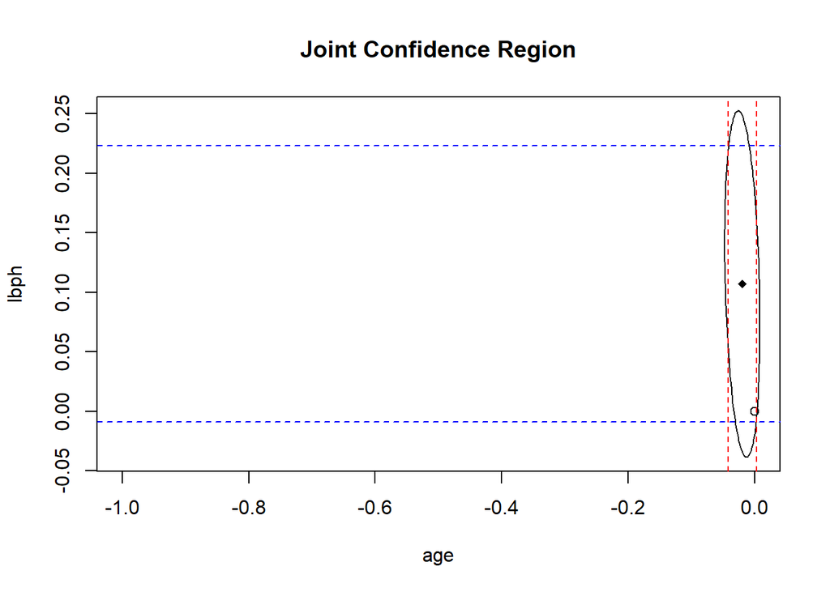

```r
plot(ellipse(g, c("age", "lbph")),
     type = "l",
     xlim = c(-1,0),
     main = "Joint Confidence Region")
points(0,0)
points(coef(g)["age"], coef(g)["lbph"],
       pch=18)
abline(v=confint(g)["age",], lty=2, col="red")
abline(h=confint(g)["lbph",], lty=2, col="blue")
```

```r
g1 <- lm(lbph ~ age  ,prostate)
g2 <- lm(lbph ~ . ,prostate)
anova(g1,g2)
```

```
## Analysis of Variance Table
##
## Model 1: lbph ~ age
## Model 2: lbph ~ lcavol + lweight + age + svi + lcp + gleason + pgg45 +
##     lpsa
##   Res.Df    RSS Df Sum of Sq      F   Pr(>F)
## 1     95 177.28
## 2     88 141.50  7    35.781 3.1788 0.004794 **
## ---
## Signif. codes:  0 '***' 0.001 '**' 0.01 '*' 0.05 '.' 0.1 ' ' 1
```

# 3. Exercise

Predict lpsa (95%) for a new patient with lcavol = 1.22692, lweight = 3.62301, age = 65, lbph = -0.3001, svi = 0.0, lcp = -0.79851, gleason = 7.0, pgg45 = 15.0. Do this again for the mean response. Using the exp() function, obtain the new prediction and mean response for psa.

```r
x0 <- data.frame(lcavol=1.22692,
                 lweight=3.62301,
                 age=65,
                 lbph=-0.3001,
                 svi=0.0,
                 lcp=-0.79851,
                 gleason=7.0,
                 pgg45=15.0)
predict(g,
        x0,
        interval="prediction",
        level=.95)
```

```
##        fit       lwr     upr
## 1 2.195654 0.7708983 3.62041
```

```r
exp(predict(g,
            x0,
            interval="prediction",
            level=.95))
```

```
##        fit      lwr      upr
## 1 8.985877 2.161707 37.35288
```

New Prediction = 8.9858 Mean Response = (lwr+upr)/2=(2.161707+37.3528)/2=19.75

# 4. Exercise

Repeat the above exercise with new patient age = 20

```r
x1 <- data.frame(lcavol=1.22692,
                 lweight=3.62301,
                 age=20,
                 lbph=-0.3001,
                 svi=0.0,
                 lcp=-0.79851,
                 gleason=7.0,
                 pgg45=15.0)
predict(g,
        x1,
        interval="prediction",
        level=.95)
```

```
##        fit      lwr      upr
## 1 3.079327 1.357826 4.800828
```

```r
exp(predict(g,
            x1,
            interval="prediction",
            level=.95))
```

```
##        fit      lwr      upr
## 1 21.74376 3.887732 121.6111
```

# 5. Exercise

For the model in exercise 1, remove all the predictors that are not significant at the 5% level.

Recompute the predictions for exercises 3 and 4. Compare CIs. On the psa scale, which CIs do you prefer?

Ans: The predictors which are significant at the 5% level are lcavol, lweight , svo taking lpsa as the response.

```r
g1 <- lm(lpsa ~ lcavol+lweight+svi, prostate)
summary(g1)
```

```
##
## Call:
## lm(formula = lpsa ~ lcavol + lweight + svi, data = prostate)
##
## Residuals:
##      Min       1Q   Median       3Q      Max
## -1.72964 -0.45764  0.02812  0.46403  1.57013
##
## Coefficients:
##             Estimate Std. Error t value Pr(>|t|)
## (Intercept) -0.26809    0.54350  -0.493  0.62298
## lcavol       0.55164    0.07467   7.388  6.3e-11 ***
## lweight      0.50854    0.15017   3.386  0.00104 **
## svi          0.66616    0.20978   3.176  0.00203 **
## ---
## Signif. codes:  0 '***' 0.001 '**' 0.01 '*' 0.05 '.' 0.1 ' ' 1
##
## Residual standard error: 0.7168 on 93 degrees of freedom
## Multiple R-squared:  0.6264, Adjusted R-squared:  0.6144
## F-statistic: 51.99 on 3 and 93 DF,  p-value: < 2.2e-16
```

```r
exp(predict(g1,
            x0,
            interval="prediction",
            level=.95))
```

```
##        fit      lwr      upr
## 1 9.498876 2.266102 39.81667
```

```r
exp(predict(g1,
            x1,
            interval="prediction",
            level=.95))
```

```
##        fit      lwr      upr
## 1 9.498876 2.266102 39.81667
```

# 6. Exercise

Test the model in exercise 5 against the model in exercise 1 at probability type I error =0.05. Which model is preferred?

```r
anova(g1,g)
```

```
## Analysis of Variance Table
##
## Model 1: lpsa ~ lcavol + lweight + svi
## Model 2: lpsa ~ lcavol + lweight + age + lbph + svi + lcp + gleason +
##     pgg45
##   Res.Df    RSS Df Sum of Sq      F Pr(>F)
## 1     93 47.785
## 2     88 44.163  5    3.6218 1.4434 0.2167
```

Inference: Since the value of F ratio is less than 2, the small model will be preferred.